# Lab 5

Y. Samuel Wang

3/3/2022

# Heteroscedasticity

In this lab, we’ll first show how to run a Bruesch Pagan Test and calculate the robust standard errors in R. We’ll use the function from the package to conduct a Bresuch Pagan test. We’ll generate data twice, once from a model that is homoscedastic and once from a model that is heteroscedastic.

```r
#install.packages("lmtest")
library("lmtest")
```

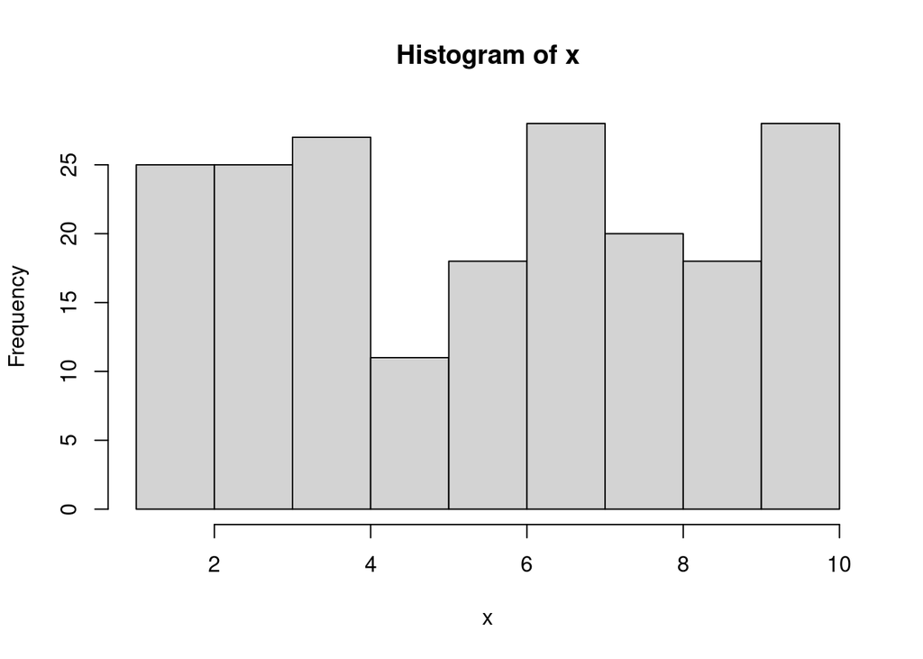

```r
n <- 200
# generate covariate X
x <- runif(n, 1, 10)
hist(x)
```

```r
# generate Y2 with homoscedasticity
sd1 <- mean(x/3)
sd1
```

```
## [1] 1.82209
```

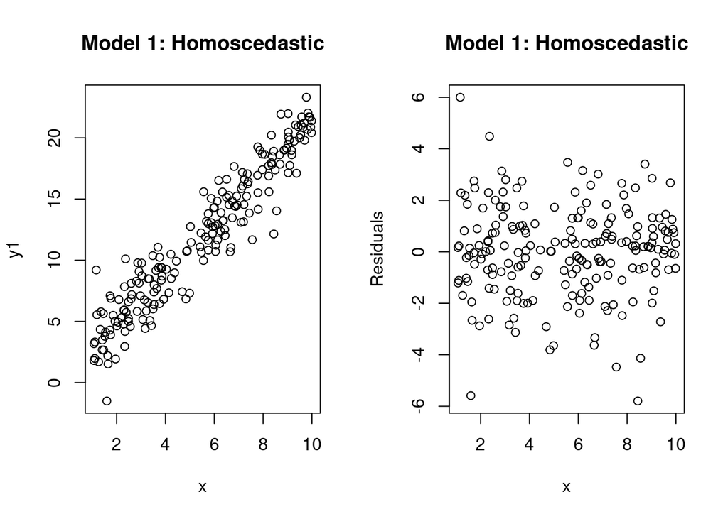

```r
y1 <- 1 + 2 * x + rnorm(n, sd = sd1)

# generate Y2 with heteroscedasticity
y2 <- 1 + 2 * x + rnorm(n, sd = x/3)

# fit linear model
mod1 <- lm(y1 ~ x)
mod2 <- lm(y2 ~ x)

par(mfrow = c(1,2))
plot(x, y1, main = "Model 1: Homoscedastic")
plot(x, mod1$res, main = "Model 1: Homoscedastic", ylab = "Residuals")
```

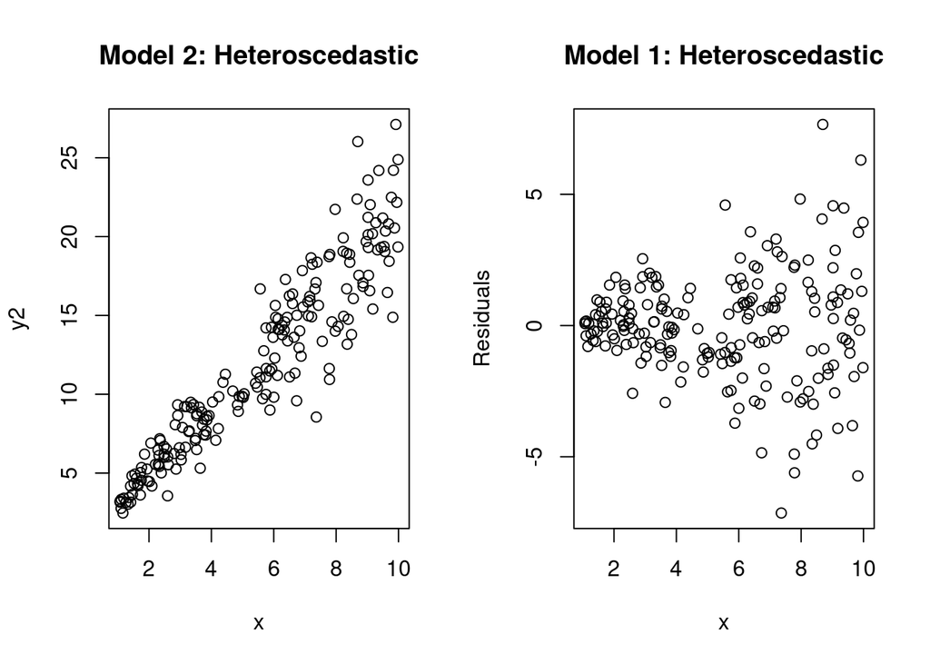

```r
par(mfrow = c(1,2))
plot(x, y2, main = "Model 2: Heteroscedastic")
plot(x, mod2$res, main = "Model 1: Heteroscedastic", ylab = "Residuals")
```

We can tell from the plots that the second model is heteroscedastic. But just to confirm, we can run a Bresuch Pagan test.

```r
# run breusch pagan test
# use the bptest function (in the lmtest package)
# takes the fitted linear model as an argument
bptest(mod1)
```

```
##
##  studentized Breusch-Pagan test
##
## data:  mod1
## BP = 1.735, df = 1, p-value = 0.1878
```

```r
bptest(mod2)
```

```
##
##  studentized Breusch-Pagan test
##
## data:  mod2
## BP = 29.675, df = 1, p-value = 5.109e-08
```

The package calculates robust standard errors.

```r
# install.packages("sandwich)
library("sandwich")

## Get model based standard errors
## vcov returns hat sigma^2 (X'X)^{-1}
## which is the estimated covariance matrix of b-hat
vcov(mod2)
```

```
##             (Intercept)            x
## (Intercept)  0.10742795 -0.015763587
## x           -0.01576359  0.002883792
```

```r
# diag gets the diagonal elements of the matrix
# these elements correspond to the estimated variance of the coefficients
# We take the square root to get the standard error
sqrt(diag(vcov(mod2)))
```

```
## (Intercept)           x
##  0.32776204  0.05370095
```

```r
## Get sandwich standard errors
## vcovHC (from the sandwich package) returns
# hat sigma^2 (X'X)^{-1} (X' W-hat X) (X'X)^{-1} which is
## the estimated covariance matrix of b-hat allowing for heteroscedasticity
# type = "HC3" is a specific way to estimate the W-hat matrix
# and is the most popular procedure
vcovHC(mod2, type = "HC3")
```

```
##             (Intercept)            x
## (Intercept)  0.05237133 -0.011547588
## x           -0.01154759  0.003191686
```

```r
# Get the standard deviation of each of
sqrt(diag(vcovHC(mod2, type = "HC3")))
```

```
## (Intercept)           x
##  0.22884784  0.05649501
```

```r
## Use the coeftest function (from the lmtest package)
# by default, the coeftest function uses the "model based" standard errors

coeftest(mod2)
```

```
##
## t test of coefficients:
##
##             Estimate Std. Error t value  Pr(>|t|)
## (Intercept) 0.936215   0.327762  2.8564  0.004742 **
## x           2.004218   0.053701 37.3218 < 2.2e-16 ***
## ---
## Signif. codes:  0 '***' 0.001 '**' 0.01 '*' 0.05 '.' 0.1 ' ' 1
```

```r
summary(mod2)
```

```
##
## Call:
## lm(formula = y2 ~ x)
##
## Residuals:
##     Min      1Q  Median      3Q     Max
## -7.1427 -1.0285  0.0764  1.0537  7.6623
##
## Coefficients:
##             Estimate Std. Error t value Pr(>|t|)
## (Intercept)   0.9362     0.3278   2.856  0.00474 **
## x             2.0042     0.0537  37.322  < 2e-16 ***
## ---
## Signif. codes:  0 '***' 0.001 '**' 0.01 '*' 0.05 '.' 0.1 ' ' 1
##
## Residual standard error: 2.062 on 198 degrees of freedom
## Multiple R-squared:  0.8755, Adjusted R-squared:  0.8749
## F-statistic:  1393 on 1 and 198 DF,  p-value: < 2.2e-16
```

```r
# Create 95% confidence intervals using model based standard errors
coefci(mod2, level = .95)
```

```
##                 2.5 %   97.5 %
## (Intercept) 0.2898624 1.582567
## x           1.8983187 2.110117
```

```r
# Instead of using the default model based standard errors
# we can feed a specific variance matrix
# and replace the default with the robust standard errors
coeftest(mod2, vcov. = vcovHC(mod2, type = "HC3"))
```

```
##
## t test of coefficients:
##
##             Estimate Std. Error t value  Pr(>|t|)
## (Intercept) 0.936215   0.228848   4.091 6.247e-05 ***
## x           2.004218   0.056495  35.476 < 2.2e-16 ***
## ---
## Signif. codes:  0 '***' 0.001 '**' 0.01 '*' 0.05 '.' 0.1 ' ' 1
```

```r
# Create 95% confidence intervals using robust standard errors
coefci(mod2, level = .95, vcov. = vcovHC(mod2, type = "HC3"))
```

```
##                 2.5 %   97.5 %
## (Intercept) 0.4849229 1.387507
## x           1.8928087 2.115627
```

# Bootstrap

## Bootstrapping difficult quantities

Suppose we have data that is drawn from an distribution. For the purposes of this lab, the important thing to note is that it’s a skewed distribution. The density is plotted below:

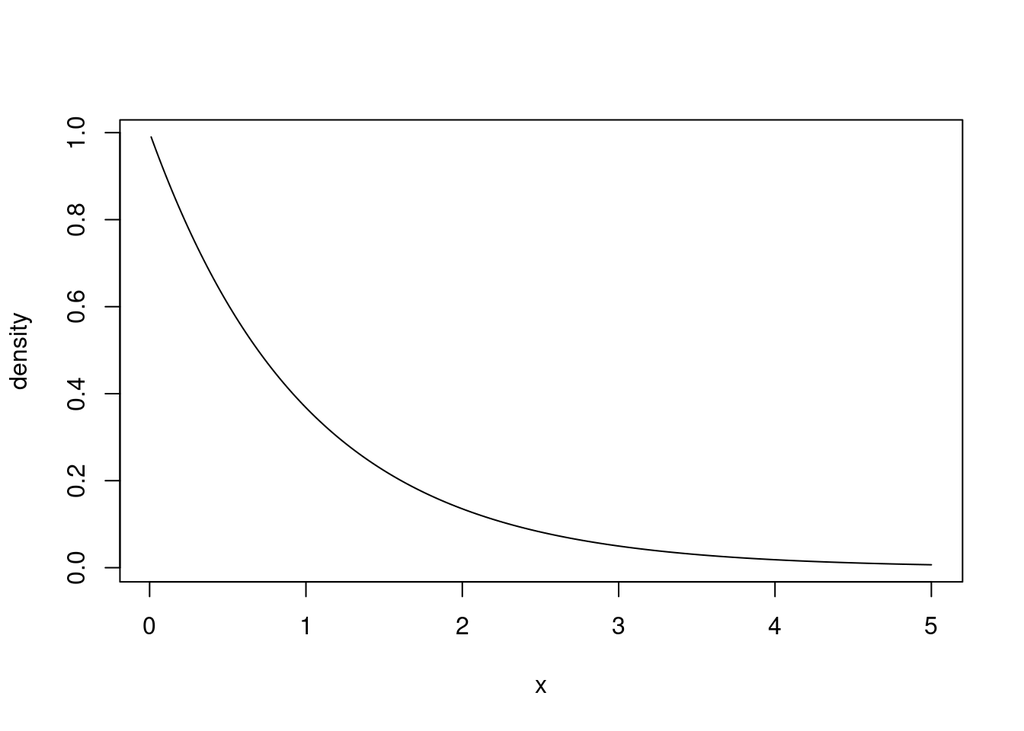

If we are interested in the mean, the central limit theorem says that the sample mean of our data will be close to a normal distribution as we get more and more observations. Thus, we can form a confidence interval in the same way that you learned in BTRY 6010. However, since the data is skewed, perhaps we’re more interested in the median. Unfortunately, there isn’t a straightforward way to get a confidence interval for the median. So we’ll use empirical bootstrap from the package.

```r
library("boot")
?boot
```

```r
set.seed(101)
n <- 20
## Draw n observations from an exponential distribution
X <- rexp(n)

# Function which we will feed into the boot function
# takes two arguments
# the data we observe
# indices which are drawn with replacement from 1 to n
# returns the statistic we are interested in (in this case the median) calculated
# on the bootstrapped sample
med.boot <- function(data, indices){
  return(median(data[indices]))
}

# The boot function takes in the data
# and requires a function used calculate the statistic of interest (in this
# case the median).
# R determines the number of times to resample the data
boot.output <- boot(data = X, statistic = med.boot, R = 500)

# calculate various types of 95% confidence intervals
# norm: estimates the standard error of the statistic using the bootstrap
# and plugs that estimate in to the normal confidence interval
# perc: is the percentage procedure which simply takes the quantiles of the
# bootstrapped statistics
# bca: is a more complicated procedure which we won't cover, but has many
# theoretical and empirical advantages
ci.output <- boot.ci(boot.output, conf = .95, type = c("norm", "perc", "bca"))

# includes negative values
# Element 1, is just the confidence level
# the confidence interval is in elements 4/5
ci.output$normal
```

```
##      conf
## [1,] 0.95 -0.1790461 1.057167
```

```r
# confidence interval from percentile procedure
# don't worry about elements 1-3, the confidence interval is in elements 4/5
ci.output$perc[c(4,5)]
```

```
## [1] 0.3170879 1.2848651
```

```r
# bca confidence interval
# don't worry about elements 1-3, the confidence interval is in elements 4/5
ci.output$bca[c(4,5)]
```

```
## [1] 0.3170879 1.2785064
```

So we can form confidence intervals for the median, but do they work like we think they should? The median for the exponential distribution is $\log(2)$. Let’s repeat the procedure many different times and see if we actually do include the median 95% of the time.

```r
# number of times we'll repeat the experiment
sim.size <- 500

n <- 20

# where we will record relevant statistics

rec <- matrix(0, sim.size, 6)
colnames(rec) <- c("Normal Coverage", "Percentile Coverage", "Bca Coverage",
                   "Normal length", "Percentile length", "Bca length")
for(i in 1:sim.size){
  # draw fresh data
  X <- rexp(n)

  # calculate the 3 different confidence intervals
  boot.output <- boot(data = X, statistic = med.boot, R = 500)
  ci.output <- boot.ci(boot.output, conf = .95, type = c("norm", "perc", "bca"))

  # check if log(2) is in the normal CI
  rec[i, 1] <- ci.output$normal[2] < log(2) & ci.output$normal[3] > log(2)
  # record size of CI
  rec[i, 4] <- ci.output$normal[3] - ci.output$normal[2]
  # check if log(2) is in the percentile CI
  rec[i, 2] <- ci.output$perc[4] < log(2) & ci.output$perc[5] > log(2)
  rec[i, 5] <- ci.output$perc[5] - ci.output$perc[4]
  # check if log(2) is in the percentile CI
  rec[i, 3] <- ci.output$bca[4] < log(2) & ci.output$bca[5] > log(2)
  rec[i, 6] <- ci.output$bca[5] - ci.output$bca[4]

}



# first three columns indicate whether the normal/percentile/bca CI's
# contained the true median (we want this to be close to .95)
# last three columns are the length of the normal/percentile/bca CI's
# We take the mean of the columns and round to 4 digits
round(colMeans(rec), 4)
```

```
##     Normal Coverage Percentile Coverage        Bca Coverage       Normal length
##              0.9260              0.9420              0.9480              0.9264
##   Percentile length          Bca length
##              0.8946              0.8647
```

#### Questions

- How do the procedures compare? Is there a particular procedure which seems to do the best in terms of coverage?
- If different procedures can give you a CI with exactly 95% coverage, how else might you decide between procedures?
- If you increase the number of samples (maybe try $n = 30$ or $50$), how does the coverage change? How does the length of the CI’s change?

## Bootstrapping Linear Models

```r
# install.packages("lmboot")
library("lmboot")

heart_data <- read.csv("~/Downloads/ischemic.csv")
names(heart_data)
```

```
##  [1] "id"            "cost"          "age"           "gender"
##  [5] "interventions" "drugs"         "er"            "complications"
##  [9] "comorbidities" "duration"
```

```r
mod <- lm(cost ~ age + gender + interventions + drugs + er + complications + comorbidities + duration,
          data = heart_data)
summary(mod)
```

```
##
## Call:
## lm(formula = cost ~ age + gender + interventions + drugs + er +
##     complications + comorbidities + duration, data = heart_data)
##
## Residuals:
##    Min     1Q Median     3Q    Max
## -29642  -1640    -18   1272  36552
##
## Coefficients:
##                Estimate Std. Error t value Pr(>|t|)
## (Intercept)   -252.6929  1448.3289  -0.174   0.8615
## age            -48.0149    24.1226  -1.990   0.0469 *
## genderother    906.5264   385.0864   2.354   0.0188 *
## interventions  800.2449    31.8848  25.098  < 2e-16 ***
## drugs         -365.5217   178.8959  -2.043   0.0414 *
## er             422.4063    75.8315   5.570  3.5e-08 ***
## complications  873.8176   665.0742   1.314   0.1893
## comorbidities   51.7655    31.3016   1.654   0.0986 .
## duration        -0.7467     1.5685  -0.476   0.6342
## ---
## Signif. codes:  0 '***' 0.001 '**' 0.01 '*' 0.05 '.' 0.1 ' ' 1
##
## Residual standard error: 4498 on 779 degrees of freedom
## Multiple R-squared:  0.5527, Adjusted R-squared:  0.5481
## F-statistic: 120.3 on 8 and 779 DF,  p-value: < 2.2e-16
```

```r
## Gives list of parameter estimates from each empirical bootstrap
# (or paired boostrap) resample
paired.output <- paired.boot(cost ~ age + gender + interventions + drugs + er + complications + comorbidities + duration,
                             data = heart_data, B = 1000)
## Gives list of parameter estimates from each wild bootstrap  resample
wild.output <- wild.boot(cost ~ age + gender + interventions + drugs + er + complications + comorbidities + duration,
                             data = heart_data, B = 1000)


## Apply takes a function (FUN) and applies it to each row or column
## of a matrix
## MAR = 1, applies the function to each row
## MAR = 2, applies the function to each column

## Get standard deviation of each column (which corresponds to the bootstrap estimates)
paired.se <- apply(paired.output$bootEstParam, MAR = 2, FUN = sd)
wild.se <- apply(wild.output$bootEstParam, MAR = 2, FUN = sd)

## Get .025 and .975 quantiles of each column
paired.pct <- apply(paired.output$bootEstParam,
                    MAR = 2, FUN = quantile, prob = c(.025, .975))
wild.pct <- apply(wild.output$bootEstParam,
                  MAR = 2, FUN = quantile, prob = c(.025, .975))


cbind(mod$coef -1.96 * paired.se, mod$coef + 1.96 * paired.se)
```

```
##                       [,1]         [,2]
## (Intercept)   -3082.286097 2576.9003862
## age             -95.066226   -0.9634842
## genderother     204.073264 1608.9795938
## interventions   640.062940  960.4267706
## drugs         -1114.923270  383.8798028
## er              235.953957  608.8585743
## complications -1276.125241 3023.7605408
## comorbidities   -18.719510  122.2504316
## duration         -3.754351    2.2609711
```

```r
cbind(mod$coef -1.96 * wild.se, mod$coef + 1.96 * wild.se)
```

```
##                       [,1]         [,2]
## (Intercept)   -3099.519890 2594.1341786
## age             -95.615585   -0.4141255
## genderother     249.872081 1563.1807766
## interventions   636.392635  964.0970756
## drugs         -1098.913279  367.8698119
## er              237.715564  607.0969672
## complications -1184.872036 2932.5073354
## comorbidities   -15.768319  119.2992411
## duration         -3.732964    2.2395844
```

```r
t(paired.pct)
```

```
##                      2.5%       97.5%
## (Intercept)   -3021.88992 2551.848531
## age             -96.15162   -2.717921
## genderother     129.50752 1548.463068
## interventions   633.86568  945.030928
## drugs         -1074.61387  407.927944
## er              233.64219  614.823943
## complications -1107.44402 3332.502381
## comorbidities   -13.51046  128.924708
## duration         -3.83535    2.295061
```

```r
t(wild.pct)
```

```
##                       2.5%       97.5%
## (Intercept)   -3152.469571 2562.696300
## age             -93.339070    1.458530
## genderother     207.367222 1541.070325
## interventions   645.186340  957.952272
## drugs         -1159.149745  316.073935
## er              244.189341  619.394752
## complications -1293.324326 2817.149469
## comorbidities   -14.744719  119.650916
## duration         -3.745873    2.170916
```

```r
confint(mod)
```

```
##                      2.5 %       97.5 %
## (Intercept)   -3095.782652 2590.3969410
## age             -95.367912   -0.6617985
## genderother     150.596448 1662.4564091
## interventions   737.654593  862.8351174
## drugs          -716.696949  -14.3465182
## er              273.548036  571.2644950
## complications  -431.732209 2179.3675088
## comorbidities    -9.680032  113.2109531
## duration         -3.825706    2.3323262
```